# Animal Adoption Rate

### Decision Tree - Adoption

```r
prevalence <- 1-table(shelter_data$Outcome.Type)[[2]]/length(shelter_data$Outcome.Type)  # calculate the proportion of salary that is the positive class
prevalence
```

```
## [1] 0.1736912
```

The prevalence is the proportion of the positive class within the target variable, in this case, the pets that are adopted from the shelter. In this data set, the prevalence is roughly 17%. This means that roughly 83% of the data is the negative class, or pets that are not adopted. This metric can be used a baseline because a model that always predicts the negative class will be correct about 83% of the time at random.

```r
dim(train)
## [1] 18519     9
dim(tune)
## [1] 3968    9
dim(test)
## [1] 3968    9
```

```r
features <- train[,c(-8)] # dropping Outcome.Type column to get just the explanatory variables in features
target <- train$Outcome.Type  # add just the Outcome.Type column to target


fitControl <- trainControl(method = "repeatedcv",  # use repeated cross validation with 5 folds and 3 repeats
                          number = 5,
                          repeats = 3,
                          returnResamp="all",
                          classProbs = TRUE,
                          allowParallel = TRUE)

tree.grid <- expand.grid(maxdepth=c(5,7,9,11))

set.seed(1984)  # set seed for reproducibility
shelter_mdl <- train(x=features,
                y=target,
                method="rpart2",#type of model uses maxdepth to select a model
                trControl=fitControl,#previously created
                tuneGrid=tree.grid,#expanded grid
                metric="ROC")#selected on of the metrics available from two variable summary.

shelter_mdl
```

```
## CART
##
## 18519 samples
##     8 predictor
##     2 classes: 'Adopted', 'Not_Adopted'
##
## No pre-processing
## Resampling: Cross-Validated (5 fold, repeated 3 times)
## Summary of sample sizes: 14816, 14815, 14815, 14816, 14814, 14816, ...
## Resampling results across tuning parameters:
##
##   maxdepth  Accuracy   Kappa
##    5        0.8751191  0.5024275
##    7        0.8796909  0.5346578
##    9        0.8841008  0.5656531
##   11        0.8844247  0.5656978
##
## Accuracy was used to select the optimal model using the largest value.
## The final value used for the model was maxdepth = 11.
```

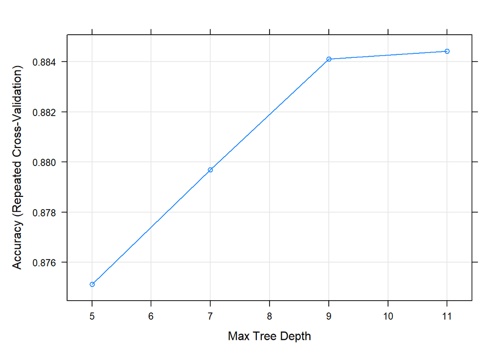

```r
plot(shelter_mdl)
```

```r
varImp(shelter_mdl)
```

```
## rpart2 variable importance
##
##                   Overall
## days_in_shelter  100.0000
## Sex               57.0850
## Age               48.8401
## Intake.Condition  27.9883
## Animal.Type       11.1253
## Intake.Type        9.7943
## Jurisdiction       0.3915
## Primary.Color      0.0000
```

Variables with greatest importance are days in the shelter, sex, age, the intake condition, and the type of animal.

```r
predictandCM(shelter_mdl,tune,"raw",tune$Outcome.Type)
```

```
## Confusion Matrix and Statistics
##
##              Reference
## Prediction    Adopted Not_Adopted
##   Adopted         419         201
##   Not_Adopted     270        3078
##
##                Accuracy : 0.8813
##                  95% CI : (0.8708, 0.8912)
##     No Information Rate : 0.8264
##     P-Value [Acc > NIR] : < 2.2e-16
##
##                   Kappa : 0.5693
##
##  Mcnemar's Test P-Value : 0.001729
##
##             Sensitivity : 0.6081
##             Specificity : 0.9387
##          Pos Pred Value : 0.6758
##          Neg Pred Value : 0.9194
##              Prevalence : 0.1736
##          Detection Rate : 0.1056
##    Detection Prevalence : 0.1562
##       Balanced Accuracy : 0.7734
##
##        'Positive' Class : Adopted
##
```

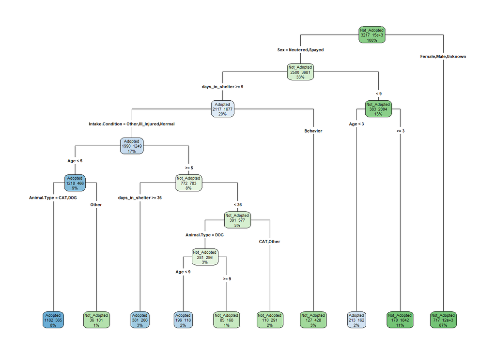

```r
rpart.plot(shelter_mdl$finalModel, type=4,extra=101)
```

```r
shelter_mdl$results
```

```
##   maxdepth  Accuracy     Kappa  AccuracySD     KappaSD
## 1        5 0.8751191 0.5024275 0.003850890 0.019545342
## 2        7 0.8796909 0.5346578 0.002661621 0.008677938
## 3        9 0.8841008 0.5656531 0.003791283 0.019207966
## 4       11 0.8844247 0.5656978 0.003857220 0.020019717
```

### Decision Tree - Rescue

```r
prevalence <- 1-table(rescue_data$Outcome.Type)[[1]]/length(rescue_data$Outcome.Type)
prevalence
```

```
## [1] 0.2804666
```

```r
dim(train)
## [1] 15303     9
dim(tune)
## [1] 3279    9
dim(test)
## [1] 3278    9
```

```r
features <- train[,c(-8)] # dropping outcome type column to get just the explanatory variables in features
target <- train$Outcome.Type


fitControl <- trainControl(method = "repeatedcv",  # use repeated cross validation with 5 folds and 3 repeats
                          number = 5,
                          repeats = 3,
                          returnResamp="all",
                          classProbs = TRUE,
                          allowParallel = TRUE)

tree.grid <- expand.grid(maxdepth=c(5,7,9,11))

set.seed(1984)  # set seed for reproducibility
rescue_mdl <- train(x=features,
                y=target,
                method="rpart2",#type of model uses maxdepth to select a model
                trControl=fitControl,#previously created
                tuneGrid=tree.grid,#expanded grid
                metric="ROC")#selected on of the metrics available from two variable summary.

rescue_mdl
```

```
## CART
##
## 15303 samples
##     8 predictor
##     2 classes: 'Not_Adopted', 'Rescued'
##
## No pre-processing
## Resampling: Cross-Validated (5 fold, repeated 3 times)
## Summary of sample sizes: 12243, 12243, 12242, 12243, 12241, 12242, ...
## Resampling results across tuning parameters:
##
##   maxdepth  Accuracy   Kappa
##    5        0.7676272  0.348522
##    7        0.7676272  0.348522
##    9        0.7676272  0.348522
##   11        0.7676272  0.348522
##
## Accuracy was used to select the optimal model using the largest value.
## The final value used for the model was maxdepth = 5.
```

```r
# plot(rescue_mdl)
varImp(rescue_mdl)
```

```
## rpart2 variable importance
##
##                   Overall
## Intake.Condition 100.0000
## Age               73.3506
## Animal.Type       64.9296
## days_in_shelter   47.7059
## Intake.Type       36.2561
## Sex               29.6066
## Jurisdiction       0.1684
## Primary.Color      0.0000
```

```r
predictandCM(rescue_mdl,tune,"raw",tune$Outcome.Type)
```

```
## Confusion Matrix and Statistics
##
##              Reference
## Prediction    Not_Adopted Rescued
##   Not_Adopted        2180     619
##   Rescued             179     301
##
##                Accuracy : 0.7566
##                  95% CI : (0.7416, 0.7712)
##     No Information Rate : 0.7194
##     P-Value [Acc > NIR] : 8.412e-07
##
##                   Kappa : 0.2942
##
##  Mcnemar's Test P-Value : < 2.2e-16
##
##             Sensitivity : 0.3272
##             Specificity : 0.9241
##          Pos Pred Value : 0.6271
##          Neg Pred Value : 0.7788
##              Prevalence : 0.2806
##          Detection Rate : 0.0918
##    Detection Prevalence : 0.1464
##       Balanced Accuracy : 0.6256
##
##        'Positive' Class : Rescued
##
```

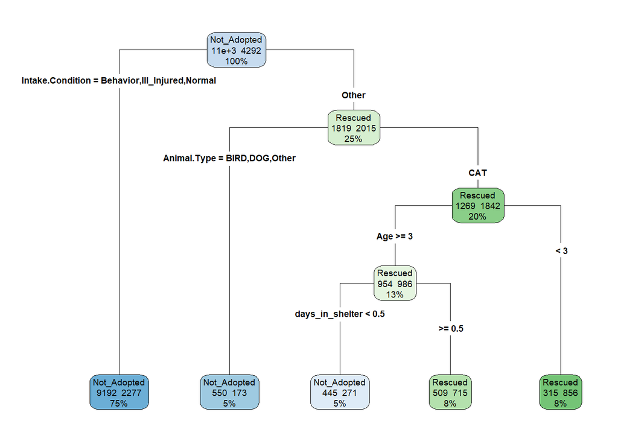

```r
rpart.plot(rescue_mdl$finalModel, type=4,extra=101)
```

```r
rescue_mdl$results
```

```
##   maxdepth  Accuracy    Kappa  AccuracySD    KappaSD
## 1        5 0.7676272 0.348522 0.007767632 0.04021767
## 2        7 0.7676272 0.348522 0.007767632 0.04021767
## 3        9 0.7676272 0.348522 0.007767632 0.04021767
## 4       11 0.7676272 0.348522 0.007767632 0.04021767
```

## Fairness Assessment

There are not protected classes because the data is on pets.

[figure not shown]

## Conclusion

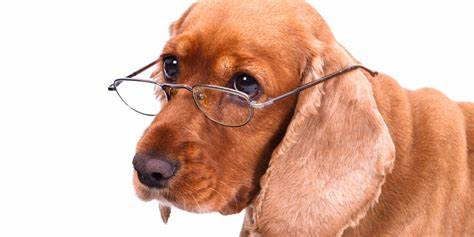

## Future work

One way that this study could be adapted in future work could be through applying different databases in different areas of the world to learn if/how adoption trends change in different places and in different cultures. Databases with more quantitative variables than the one we used from the Long Beach area would be especially useful, as we wanted to try clustering in our data analysis but didn’t have enough quantitative variables (i.e. weight) to do so. One reason to try clustering is because of the possibility of over-fitting with kNN analysis, which we experienced a bit throughout the process.